# Lab 9 - ANCOVA and missing data

Daniel Runcie.

# Using Covariates in an ANOVA

Blocking and using covariables are related techniques for reducting the amount of variation that is unexplained by the experimental model (i.e. error) so that treatment means are measured with greater precision and power.

To use blocks, you must be able to identify groups of experimental units that will be similar *a priori*. If successful, blocks control for *all* factors that differ among groups of experimental units. The problemm is that the more blocks you use, the fewer degrees of freedom you have to estimate experimental error. Also, if experimental error is caused by gradients across the experimental units, it can be difficult to find groups of eu’s that are similar. Divisions among blocks can be fairly arbitrary.

Covariates are another technique to control for variation in experimental units. As with blocks, observations are corrected for uncontrolled factors that differ among experimental units. But instead of using the mean response within a block as the correction factor, a separate measure on the same experimental unit is used as the correction factor. The correction itself works very similarly to that for incomplete blocks.  
Treatment means are estimated *marginally* over the whole range of the covariate (ie averaged) so that the treatment means can be compared.

The advantage of covariates is that each covariate *costs* only a single degree of freedom, because we assume that the relationship between covariate and response is linear. Non-linear relationships, and covariate*treatment interactions both weaken the analysis, just as they do for blocks, and so their effects should be assessed by model diagonstics.

## Example 1

A grower would like to test the effect of three different pesticides on yield in common bean. The grower plants a large field with common bean and divides the field into 6 homogeneous field sections. Each section is divided into 3 equal subsections, which are randomly assigned one of the 3 pesticides. The grower knows that the field has small patches with different levels of organic matter that can affect yield potential. Before starting the experiment, he measured the organic matter content of each subsection in grams of organic matter per kilogram of soil. At the end of the season, the grower measured grain yield of each experimental unit in bushels per acre.

### Prep the data

Load the data, check:

```r
beans <- read.csv('bean_yield.csv')
str(beans)
```

```
'data.frame':   18 obs. of  4 variables:
 $ Field.section: int  1 2 3 4 5 6 1 2 3 4 ...
 $ Pesticide    : Factor w/ 3 levels "A","B","C": 1 1 1 1 1 1 2 2 2 2 ...
 $ Yield        : num  28.1 37.8 36.9 41.6 35.2 41.6 36.2 28.4 40.3 47.1 ...
 $ OrgMat       : num  0.8 1.22 1.43 1.45 1.33 1.8 1.02 0.7 1.39 1.68 ...
```

`Field.section` needs to be converted to a factor

```r
beans$Field.section = factor(beans$Field.section)
```

### Experimental design

| Structure | Variable | Type | # levels | Experimental Unit |
| --- | --- | --- | --- | --- |
| Treatment | Pesticide | Categorical | 3 | Plot |
| Design | Field.Section | Categorical | 6 |  |
|  | Pesticide:Field.Section | Categorical | 18 |  |
|  | Plot | Categorical | 18 |  |
| Covariate | OrgMat | Numeric | 18(1) |  |
|  | OrgMat:Pesticide | Numeric | 18(3) |  |
|  | OrgMat:Field.Section | Numeric | 18(6) |  |
|  | OrgMat:Pesticide:Field.Section | Numeric | 18(18) |  |
| Response | Yield | Numeric | 18 |  |

The only new feature here is the section for **Covariates**.

The *Design* section is like a standard RCBD. We list the Treatment:Block combinations here because they are a potential source of variation. However, they are aliased with Plot, and have the same number of levels as Yield, so will not enter into our model.

> Question: Why is Experimental Unit **Plot** instead of **Pesticide:Field.Section**? Do you agree with this choice?

The **Covariate** section is new. In it, we describe potential ways that the covariate could enter into our analysis. The interpretation of the rows in the table is:

- **OrgMat**: The average effect of OrgMat on Yield
- **OrgMat:Pesticide**: The unique effects of OrgMat on Yield for each Pesticide treatment separately.
- **OrgMat:Field.Section**: The unique effects of OrgMat on Yield, for each Field.Section separately.
- **OrgMat:Pesticide:Field.Section**: The unique effects of OrgMat, on Yield for each combination of Pesticide treatment and Field.Section separately.

These are really just the same as Block:Treatment combinations (where treatment effects may vary across blocks). Here, the effects of OrgMat on Yield may vary across either blocks or treatments.

Just like in the Design part of the table, we’ve included all possible Covariates here, even ones that are not possible (or useful) to include in our final model.

The other new feature of the Covariate section is the *# levels* section. Here we list two numbers: 18(1), or 18(3), etc.

The first number is the number of unique values for the covariate. Since the covariate was measured separately for each of the 18 plots, there are 18 unique numbers. We can verify this like this:

```r
length(unique(beans$OrgMat))
```

```
[1] 18
```

> In some designs, we may have a covariate measured on other experimental units, rather than the observational unit. For example, in a split plot, we may measure a covariate on the MainPlot, rather than on each SubPlots. In this case, the first number would be the number of MainPlots.

The second number is the number of unique groups for the Covariate. For example, there are 3 Pesticides, so the *OrgMat:Pesticide* variable has three Yield ~ OrgMat effects, one for each Pesticide.

### Linear model

We write a linear model for analyses with covariates similarly to analyses with incomplete blocks.

> Notes: Similarly to models with Blocks, after writing a fully-specified model, we will often examine whether it is reasonable to simplify the model by removing Block:Treatment or Covariate:Treatment interaction terms. Ideally, when using Blocks or Covariates, the effects of the Treatments are consistant across Blocks or across the range of the covariates, so these terms are not necessary.

Start with a fully-specified model. The following rules apply:

1. Include all terms in the design table except:
- Drop any Design terms that have the same number of levels as the Response.
- For sets of Design terms with the same number of levels, check that the levels are not aliased (ex. use `table()`). If they are, keep only one.
- If one of these is an experimental unit, be sure to keep that term if possible!
- Drop any Covariate terms that have the same number of groups (second number) as the Response
- Drop any Covariate terms that have the same number of unique values (first number) as groups (second number)
- For sets of terms for the same covariate with the same number of groups, check that the groups are not aliased (ex. use `table()`). If they are, keep only one.
2. Put Covariate terms first, then Design terms, then treatment terms. Treatment:Covariate terms can go at the end. Treatment:block terms should ideally be made into a new model term (interaction(Treatment,block)) so that R will keep them at the front of the model.
- If the grouping variable is random, the format is (0+Covariate|Group) instead of Covariate:Group

Following these rules, we end up with the following model:

```r
full_model <- lm(Yield ~ OrgMat + Field.section + OrgMat:Field.section +
                   Pesticide + OrgMat:Pesticide, beans)
```

### Checking model assumptions

Before analyzing this model, we should consider the model assumptions. For analyses with covariates, we assume:

1. The covariate is independent of the treatment.
2. The covariate is linearly correlated with the response, with the same slope across treatments (and blocks)
3. The model errors are normally distributed and with similar variance across treatments and values of the blocks and covariates.

Assumption 3 is critical, and is the same as for every other linear model, and assessing it will following the same techniques.

Assumptions 1 and 2 are unique to covariates. These are actually not hard rules, but the utility of the covariates will be reduced if either is violated.

**Assumption 1:** In this experiment, *OrgMat* was measured before treatments were applied. Therefore it must be independent of the treatments. Covariates measured during or after the experiment tend to be less useful because the treatment can affect their values directly, and then indirectly affect the response. However, it is still possible that due to random chance, certain treatment levels have different average values of the covariate. If so, this will **decrease** our power. We can test this by treating the covariate as a response in an ANOVA.

```r
cov_model <- lm(OrgMat ~ Field.section + Pesticide, beans)
anova(cov_model)
```

```
Analysis of Variance Table

Response: OrgMat
              Df  Sum Sq  Mean Sq F value  Pr(>F)
Field.section  5 1.14878 0.229756  4.7616 0.01739 *
Pesticide      2 0.08321 0.041606  0.8623 0.45136
Residuals     10 0.48252 0.048252
---
Signif. codes:  0 ‘***’ 0.001 ‘**’ 0.01 ‘*’ 0.05 ‘.’ 0.1 ‘ ’ 1
```

> We see that OrgMat varies among the 6 field sections. However, there is little difference among the three Pesticides. The variation among field sections will not negatively affect our analysis since we are not interested in differences among the field sections.

> Had OrgMat varied a lot among Pesticide treatments (ie large Sum Sq), we might decide not to use it as a covariate.

**Assumption 2:** The best way to verify that the Covariate is linearly related to the Response is to make a scatter-plot of the data.

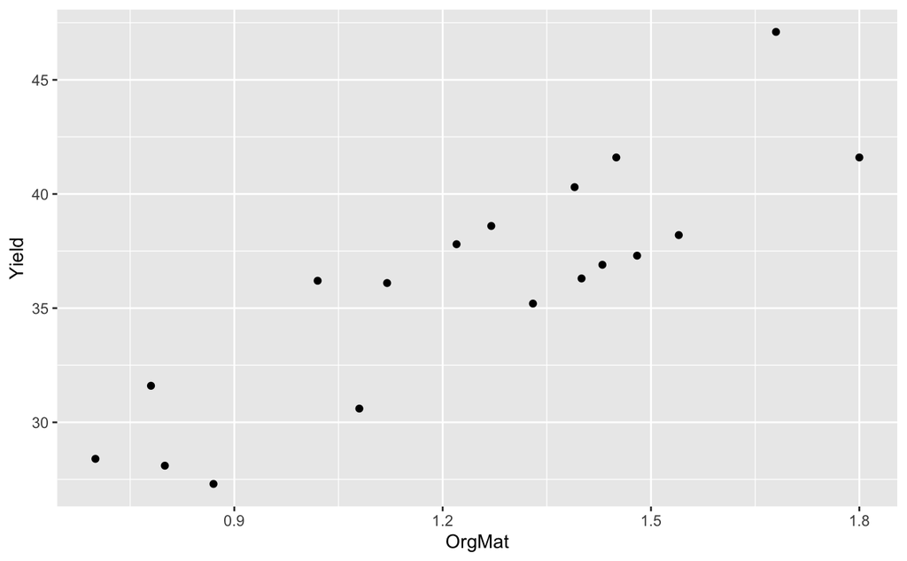

```r
ggplot(beans,aes(x=OrgMat,y=Yield)) + geom_point()
```

> The relationship looks linear. There is no reason to consider more complex (ie polynomial) models for the covariate.

We also want to evaluate whether the Response~Covariate relationship variates among treatments. We can do this visually by coloring the points by Pesticide, and fitting lines separately to each group

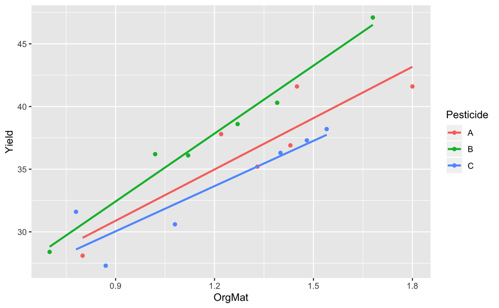

```r
ggplot(beans,aes(x=OrgMat,y=Yield)) + geom_point(aes(color = Pesticide)) + geom_smooth(aes(color = Pesticide),se=F,method='lm')
```

> The slopes look slightly different. The differences among Pesticides appears to be smaller when there is little Organic Matter than when there is a lot. This indicates that might might need to report the effect of Pesticide differences **as a Function of OrgMat**. This certainly complicates the analysis!

> However, is this change in treatment differences large enough to matter?

We can use our full model to evaluate this using an ANOVA

```r
anova(full_model)
```

```
Analysis of Variance Table

Response: Yield
                     Df Sum Sq Mean Sq F value  Pr(>F)
OrgMat                1 353.83  353.83 80.5544 0.01219 *
Field.section         5  22.87    4.57  1.0414 0.55630
Pesticide             2  56.97   28.49  6.4852 0.13360
OrgMat:Field.section  5  15.61    3.12  0.7108 0.67245
OrgMat:Pesticide      2   8.76    4.38  0.9977 0.50058
Residuals             2   8.78    4.39
---
Signif. codes:  0 ‘***’ 0.001 ‘**’ 0.01 ‘*’ 0.05 ‘.’ 0.1 ‘ ’ 1
```

> From this, we find little evidence that the differences among Pesticides is affected by Orgmat (small Sum Sq, large P-value). Therefore, it is reasonable to assume a constant relationship.

> It also appears reaonsable to assume the effects of OrgMat on Yield are constant across field sections. (Why?) So we can safetly drop this term from our model too.

Given these, we can use the simplified reduced model:

```r
reduced_model <- lm(Yield ~ OrgMat + Field.section + Pesticide, beans)
```

**Assumption 3**: Once we have decided on our final model, we run the standard diagnostics on it:

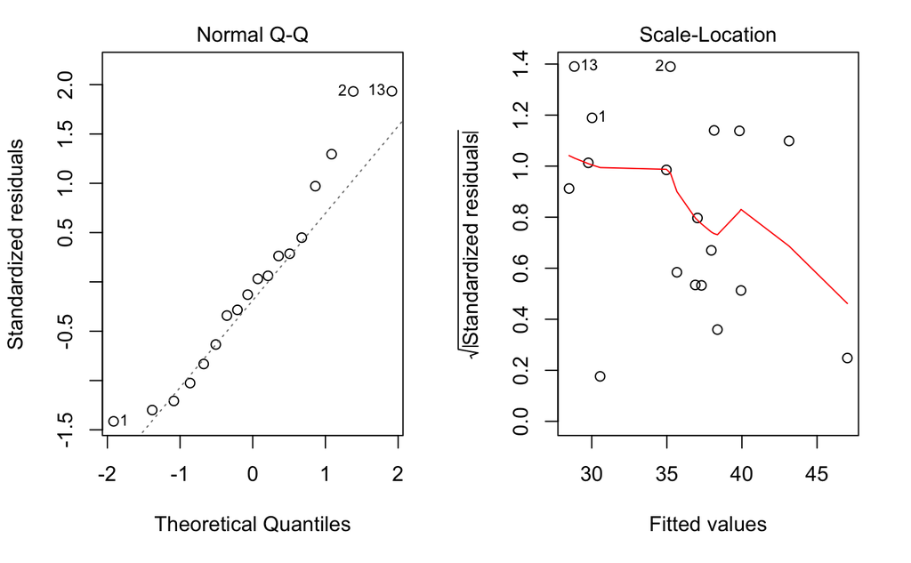

```r
par(mfrow=c(1,2))
plot(reduced_model,which=2:3)
```

> No large problems here. There are some moderate outliers, and maybe some increase in variance for lower values of yield. So we should be somewhat cautious about our results, but it’s OK to continue.

### Analysis

The analysis now follows as normal:

Evaluate whether there is any difference among Pesticides:

```r
anova(reduced_model)
```

```
Analysis of Variance Table

Response: Yield
              Df Sum Sq Mean Sq F value    Pr(>F)
OrgMat         1 353.83  353.83 96.0332 4.234e-06 ***
Field.section  5  22.87    4.57  1.2416   0.36568
Pesticide      2  56.97   28.49  7.7313   0.01111 *
Residuals      9  33.16    3.68
---
Signif. codes:  0 ‘***’ 0.001 ‘**’ 0.01 ‘*’ 0.05 ‘.’ 0.1 ‘ ’ 1
```

Compure pairwise differences among pesticides

```r
reduced_model_means = emmeans(reduced_model,specs = 'Pesticide')
contrast(reduced_model_means,method='pairwise')
```

```
 contrast estimate   SE df t.ratio p.value
 A - B      -3.307 1.18  9 -2.813  0.0484
 A - C       0.842 1.18  9  0.714  0.7617
 B - C       4.149 1.11  9  3.744  0.0115

Results are averaged over the levels of: Field.section
P value adjustment: tukey method for comparing a family of 3 estimates
```

> We can distinguish A and C from B.

> Note: The SE’s are different for each contrast. Why? The design was an RCBD. However, covariates act like incomplete blocks, and so analyses with covariates have properties more like incomplete block designs.

### Compare to analysis without covariate.

Did we gain anything by using this as a covariate?

We could re-run the analysis without a covariate, just as an RCBD:

```r
rcbd_model <- lm(Yield ~ Field.section + Pesticide, beans)
anova(rcbd_model)
```

```
Analysis of Variance Table

Response: Yield
              Df  Sum Sq Mean Sq F value  Pr(>F)
Field.section  5 236.820  47.364  2.7780 0.07945 .
Pesticide      2  59.523  29.762  1.7456 0.22374
Residuals     10 170.497  17.050
---
Signif. codes:  0 ‘***’ 0.001 ‘**’ 0.01 ‘*’ 0.05 ‘.’ 0.1 ‘ ’ 1
```

```r
rbcd_model_means = emmeans(rcbd_model,specs = 'Pesticide')
contrast(rbcd_model_means,method = 'pairwise')
```

```
 contrast estimate   SE df t.ratio p.value
 A - B      -0.917 2.38 10 -0.385  0.9224
 A - C       3.317 2.38 10  1.391  0.3814
 B - C       4.233 2.38 10  1.776  0.2266

Results are averaged over the levels of: Field.section
P value adjustment: tukey method for comparing a family of 3 estimates
```

> All confidence interavls are bigger. Therefore including the covariate did improve our ability to describe the among-Pesticide differences

Perhaps more interestingly, we could test whether once we’ve included the covariate, we really needed to block by Field.section. We lose 5 DfE from the Field.section blocks. But we know from above that the covariate differs among Field sections, and in our ANOVA (with the covariate), field.section did not explain much variation. Here’s the model ignoring these blocks:

```r
cov_only_model <- lm(Yield ~ OrgMat + Pesticide,beans)
anova(cov_only_model)
```

```
Analysis of Variance Table

Response: Yield
          Df Sum Sq Mean Sq F value    Pr(>F)
OrgMat     1 353.83  353.83 85.5597 2.432e-07 ***
Pesticide  2  55.11   27.55  6.6628  0.009267 **
Residuals 14  57.90    4.14
---
Signif. codes:  0 ‘***’ 0.001 ‘**’ 0.01 ‘*’ 0.05 ‘.’ 0.1 ‘ ’ 1
```

```r
cov_only_model_means = emmeans(cov_only_model,specs = 'Pesticide')
contrast(cov_only_model_means,method = 'pairwise')
```

```
 contrast estimate   SE df t.ratio p.value
 A - B       -2.99 1.20 14 -2.501  0.0619
 A - C        1.17 1.20 14  0.977  0.6024
 B - C        4.16 1.17 14  3.543  0.0085

P value adjustment: tukey method for comparing a family of 3 estimates
```

> Our analysis is actually more powerful with only the covariate, not the blocks! Why?

> It’s because the Field.sections are really not great blocks. There’s a lot of within-block variation (caused by variation in OrgMat). So the 5 DfE are not well used by the blocks. Directly modeling the effect of OrgMat (instead of trying to block by it) proves more effective here.

## Special notes on ANOVA with covariates

Unfortunately, analyses with covariates provide challenges to R’s default ANOVA functions, especially when there are multiple covariates and/or blocks in an analysis. As an example, say we wanted to analyse the fully-specified model we used above:

```r
full_model <- lm(Yield ~ OrgMat + Field.section + OrgMat:Field.section +
                   Pesticide + OrgMat:Pesticide, beans)
anova(full_model)
```

```
Analysis of Variance Table

Response: Yield
                     Df Sum Sq Mean Sq F value  Pr(>F)
OrgMat                1 353.83  353.83 80.5544 0.01219 *
Field.section         5  22.87    4.57  1.0414 0.55630
Pesticide             2  56.97   28.49  6.4852 0.13360
OrgMat:Field.section  5  15.61    3.12  0.7108 0.67245
OrgMat:Pesticide      2   8.76    4.38  0.9977 0.50058
Residuals             2   8.78    4.39
---
Signif. codes:  0 ‘***’ 0.001 ‘**’ 0.01 ‘*’ 0.05 ‘.’ 0.1 ‘ ’ 1
```

Our goal is to evaluate whether there is any effect of Pesticide. There are two relevant rows of the ANOVA table: **Pesticide** and **OrgMat:Pesticide**. We’re looking at both, so we’d need to adjust our alpha for two tests.

> However, note that the two interaction terms are reported **AFTER** Pesticide. Since the covariates are really incomplete blocks, we want to test Pesticide after *OrgMat:Field.section*.

It’s difficult to do this directly in R. Remember that R’s ANOVA table is formed internally by sequentially dropping terms and monitoring how `Sum Sq` increases in reduced models. Unfortunately, the `anova()` function is not flexible in what order it chooses to drop terms. It will always drop all interactions terms before any main effect terms.

So, to do this right, you have to manually drop the terms in the correct order. We can do this with the `update` function. To use `update()`, you give it the original model, and then specify which terms to remove from the model.

Following the normal strategy for testing for ANY Pesticide effect when there is the chance of interactions, we first test *OrgMat:Pesticide*, and then if it’s not siginificant, we then test (*OrgMat:Pesticide + Pesticide*)

1. To test the importance of the *OrgMat:Pesticide* term, fit a new model without this term.

```r
no_OrgMatTrt <- lm(Yield ~ OrgMat + Field.section + OrgMat:Field.section +
                   Pesticide, beans)
```

Then, use `anova()` to compare the full and reduced model.

```r
anova(no_OrgMatTrt,full_model)
```

```
Analysis of Variance Table

Model 1: Yield ~ OrgMat + Field.section + OrgMat:Field.section + Pesticide
Model 2: Yield ~ OrgMat + Field.section + OrgMat:Field.section + Pesticide +
    OrgMat:Pesticide
  Res.Df    RSS Df Sum of Sq      F Pr(>F)
1      4 17.550
2      2  8.785  2    8.7646 0.9977 0.5006
```

> This is not siginificant (p > alpha), so we will move on to testing for a main effect of Pesticide.
2. Now, starting from the no-interaction model, now drop the Pesticide main effect, and compare this model to the no-interaction model

```r
no_trt_model <- lm(Yield ~ OrgMat + Field.section + OrgMat:Field.section, beans)
anova(no_trt_model,no_OrgMatTrt)
```

```
Analysis of Variance Table

Model 1: Yield ~ OrgMat + Field.section + OrgMat:Field.section
Model 2: Yield ~ OrgMat + Field.section + OrgMat:Field.section + Pesticide
  Res.Df    RSS Df Sum of Sq      F Pr(>F)
1      6 44.009
2      4 17.550  2     26.46 3.0154  0.159
```

The p-value for this comparison is the p-value for the 2nd test (of no effect of Pesticide at all). Because it’s a second test, we would compare its p-value to alpha/2. It’s also not significant here. So we conclude we have no evidence of an effect of Pesticide.

> Question: Why do we come to this conclusion here, while we found evidence of an effect above?

**Fortunately**, this problem does not affect the *emmeans* function, so you don’t have to wory about it for measuring treatment effects themselves. Also, it generally isn’t a problem for the `anova(,mode='K')` function for `lmer()` models.

Finally, I mentioned in class that you can get the same answers using a Type III anova. To do this, use the `Anova` function from the `car` package. We’ll get the same answer as above for `Pesticide` this way. Note: we’re using the reduced model without the OrgMat.Pesticide interaction for this test. This is equivalent to test 2. above.

```r
Anova(no_OrgMatTrt,type='III')
```

```
Anova Table (Type III tests)

Response: Yield
                      Sum Sq Df F value Pr(>F)
(Intercept)          19.3693  1  4.4148 0.1035
OrgMat                1.3082  1  0.2982 0.6141
Field.section        13.4576  5  0.6135 0.7003
Pesticide            26.4596  2  3.0154 0.1590
OrgMat:Field.section 15.6110  5  0.7116 0.6467
Residuals            17.5496  4
```